# Homework 8

solutions

## Problem 1: Permutation testing for correlatedness 4pts

We mentioned in lecture that independence and uncorrelatedness are usually things that we have to assume of our data, but that there are, in some settings, ways to detect the presence or absence of dependence. This problem will give an example of that, using our old friend the permutation test.

Suppose that we observe pairs $(X_i, Y_i)$ where $X_i, Y_i \in \mathbb{R}$ for each $i=1,2,\dots,n$, with all $n$ pairs being independent of one another. That is, $(X_i,Y_i)$ is independent of $(X_j,Y_j)$ for $i \neq j$.

Most typically, we think of these as predictor-response pairs. For example, the $X_i$ might represent years of education and $Y_i$ might represent income at age 30, and we want to predict $Y$ from a given value of $X$. These kinds of problems are probably familiar to you from your discussion of regression in STAT240, and that’s a problem we’ll return to in a couple of weeks. For now, though, let’s forget about trying to estimate a regression coefficient or predict anything and instead just try to assess whether or not the $X$s and $Y$s are correlated at all.

If $X_i$ and $Y_i$ are completely uncorrelated over all $i=1,2,\dots,n$, then, much like in permutation testing, it shouldn’t matter what order the $Y$s appear with respect to the $X$s. That is, we should be able to shuffle the responses (i.e., the $Y_i$ terms) and not much should change in terms of how the data “looks”. In particular, the correlation between the $X$s and $Y$s should not change much on average.

### Part a: reading data, plotting and the eyeball test 1pts

The following code reads the horsepower (`hp`) and miles per gallon (`mpg`) columns from the famous `mtcars` data set (see `?mtcars` for background or a refresher).

```r
hp <- mtcars$hp
mpg <- mtcars$mpg
```

Create a scatter plot of the data and state whether or not you think the variables `hp` and `mpg` are correlated, based on the plot (and explain what in the plot makes you think this). There is no need to calculate any statistics here– just look at the data and describe what you see and what it suggests to you.

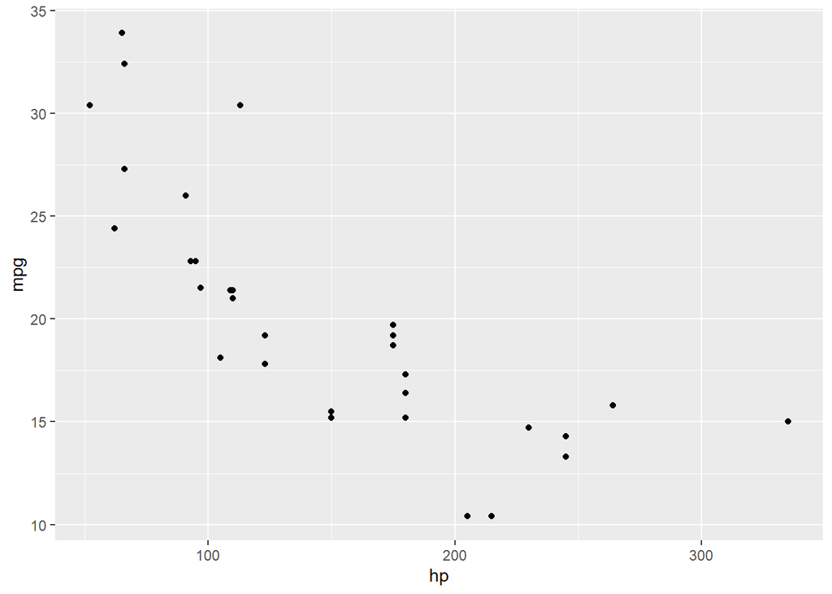

```r
ggplot(mtcars, aes(x = hp, y = mpg)) +
    geom_point()
```

### Part b: testing for correlation 3pts

Use a permutation test to assess whether or not the vectors `hp` and `mpg` are correlated. Pick a reasonable level $\alpha$ for your test and accept or reject the null hypothesis (letting $H$ be the RV representing horsepower and $M$ be the RV representing miles per gallon) accordingly.

$$H_0 : \rho_{H, M} = 0$$

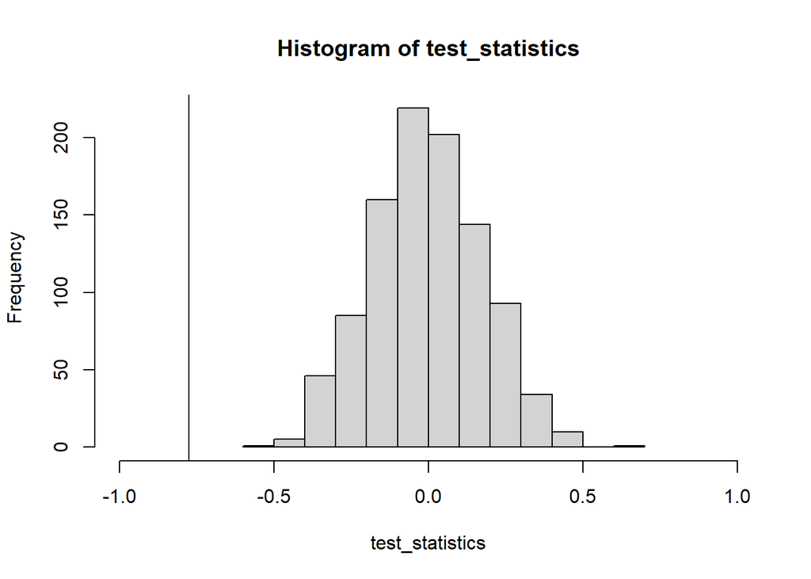

```r
permutation = function(hp, mpg){
  hp_length = length(hp)
  shuffled_data = sample(hp, size = hp_length, replace = FALSE)
  return(cor(shuffled_data, mpg))
}

NMC = 1e3
test_statistics = rep(0, NMC)
for(i in 1:NMC) {
  test_statistics[i] = permutation(hp, mpg)
}

hist(test_statistics, xlim = c(-1, 1))
abline(v = cor(hp, mpg), col = "black")
```

Be sure to clearly explain your reasoning and give a basic explanation of the procedure you are following. Imagine that you are writing for a fellow STAT340 student, rather than for your professor or TA.

**Hint:** remember, the basic permutation recipe is to shuffle the data and then compute the test statistic on the shuffled data. In this case, the “right” test statistic is clearly… (you’ll have to decide, but there are one or two pretty obvious choices), and shuffling the data just corresponds to permuting the entries of either `hp` or `mpg` (no need to permute both, because shuffling one vector effectively shuffles all pairings).

```r
p_val = sum(test_statistics <= cor(hp, mpg))/NMC
p_val
```

```
## [1] 0
```

I chose the correlation between hp and mpg as the test statistic. To assess its significance, I defined a permutation function that shuffles the hp values (using sample()) while keeping mpg fixed, then returns the correlation between the shuffled hp and original mpg. I ran this function 1,000 times as part of a Monte Carlo simulation and stored the results in a vector. Finally, I plotted the distribution of the simulated correlations in a histogram and added a vertical line showing the original correlation. Since the observed correlation lies far outside the range of simulated values and the p-value is approximately 0, we conclude there is strong statistical evidence that hp and mpg are correlated.

## Problem 2: Catamaran (8pts, 2 pts each)

Startup pet supply company Catamaran is trying to better understand the spending behavior of its customers. In particular, the company wants to find simple ways to predict how much customers will spend on Catamaran products from their purchases of just one such product: cat litter.

A (sadly, fictional) data set is stored in the file `catamaran.csv`, available from [here](https://pages.stat.wisc.edu/~bwu62/catamaran.csv). Download this file and save it in the same directory as your working directory (you can check this directory with `getwd()`). The data frame encoded in this file stores two columns:

1. The column titled `litter` is the amount of cat litter, in pounds, purchased by a customer in the past year (you’ll see in the data that Catamaran sells litter in three-pound increments; no, I don’t think that’s a realistic increment in which to sell cat littler. Fictional data is fun!).
2. The column titled `spending` is the amount of money, in dollars, that a customer has spent on Catamaran products (including cat litter) in the past year.

The following block of code loads the data in this file into a data frame `catamaran`.

```r
catamaran = read.csv('https://pages.stat.wisc.edu/~bwu62/catamaran.csv')
```

### Part a) inspecting the data

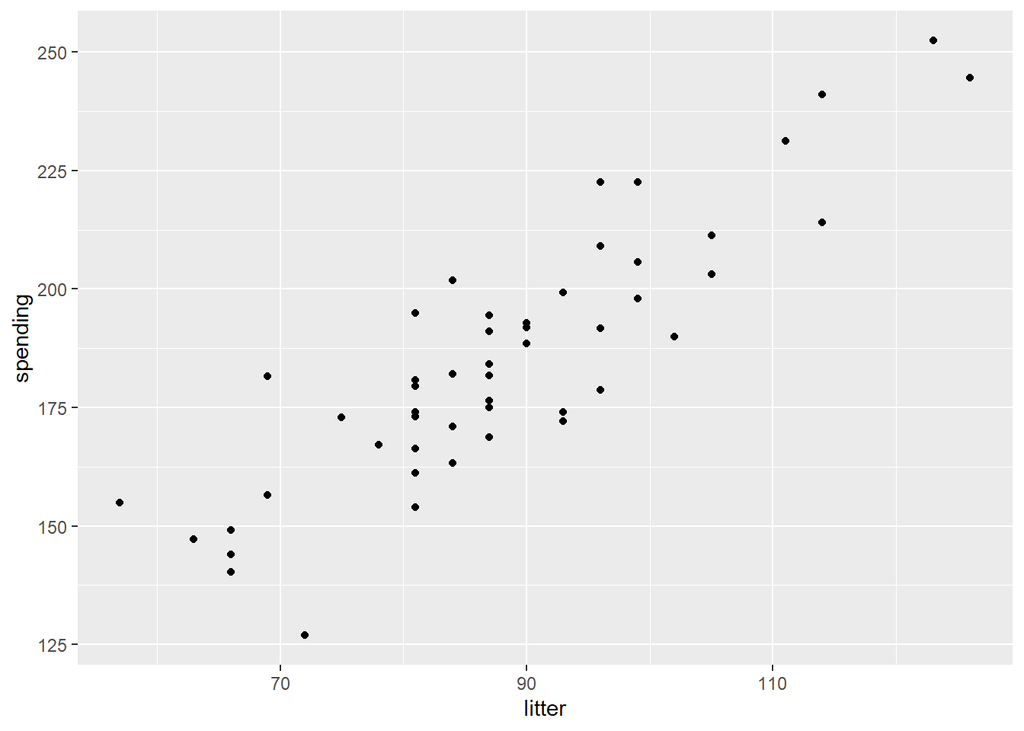

```r
ggplot(catamaran, aes(x = litter, y = spending)) +
    geom_point()
```

I see a positive linear trend in this data, and from loosely looking at the scatter plot, I would guess the slope to be around 2.3.

### Part b) fitting a model

Fit a linear model to the Catamaran data, regressing spending against the amount of litter purchased (and an intercept term).

Store the estimated intercept in a variable called `cat_intercept_hat`, and store the estimated coefficient of `litter` in a variable called `cat_slope_hat`. Don’t forget to use the `unname()` function to strip the labels off of these, ensuring that these two variables just store numbers.

```r
catamaran_lm = lm(spending ~ 1 + litter, data = catamaran)
summary(catamaran_lm)
```

```
##
## Call:
## lm(formula = spending ~ 1 + litter, data = catamaran)
##
## Residuals:
##     Min      1Q  Median      3Q     Max
## -32.405  -8.080  -0.167   7.658  27.083
##
## Coefficients:
##             Estimate Std. Error t value Pr(>|t|)
## (Intercept)  44.3555    11.3027   3.924 0.000277 ***
## litter        1.5966     0.1266  12.614  < 2e-16 ***
## ---
## Signif. codes:  0 '***' 0.001 '**' 0.01 '*' 0.05 '.' 0.1 ' ' 1
##
## Residual standard error: 13.14 on 48 degrees of freedom
## Multiple R-squared:  0.7682, Adjusted R-squared:  0.7634
## F-statistic: 159.1 on 1 and 48 DF,  p-value: < 2.2e-16
```

```r
cat_intercept_hat = unname(catamaran_lm$coefficients[1])
cat_slope_hat = unname(catamaran_lm$coefficients[2])
```

### Part c) interpreting the model

Based on these estimates, the purchase of one additional pound of cat litter per year is associated with how many more dollars per year spent on Catamaran products?

Each additional pound of cat litter purchased per year is associated with an increase of 1.60 in annual spending on Catamaran products. This is based on the equation 1.60x + 44.36; plugging in x = 1 results in an increase of 1.60.

As we mentioned above, Catamaran sells cat littler in three-pound units. Thus, a more natural question is: the purchase of one additional three-pound unit (i.e., three additional pounds) of cat littler is associated with an increase of how many more dollars per year spent on Catamaran products?

The purchase of one additional three-pound unit of cat litter is associated with an increase of $4.80 more dollars per year spent on Catamaran products (1.60 * 3).

Perhaps a more sane increment in which to sell cat litter would be twenty-pound bags. Based on your estimated coefficients, an additional twenty pounds of cat litter purchased per year is associated with an increase of how many more dollars per year spent on Catamaran products?

An additional twenty pounds of cat litter purchased per year is associated with an increase of $32 more dollars per year spent on Catamaran products (1.60 * 20).

### Part d) generating a confidence interval

Of course, Catamaran’s data is noisy, so there is uncertainty in our estimate of the coefficients in our model.

Create a Q-Q plot to verify that the residuals of our model are approximately normal. Do you see anything unusual? You probably won’t– the observation errors in this fake data really are normal. Still, take a look just to be sure; it’s a good habit to always at least briefly check the appropriateness of your model.

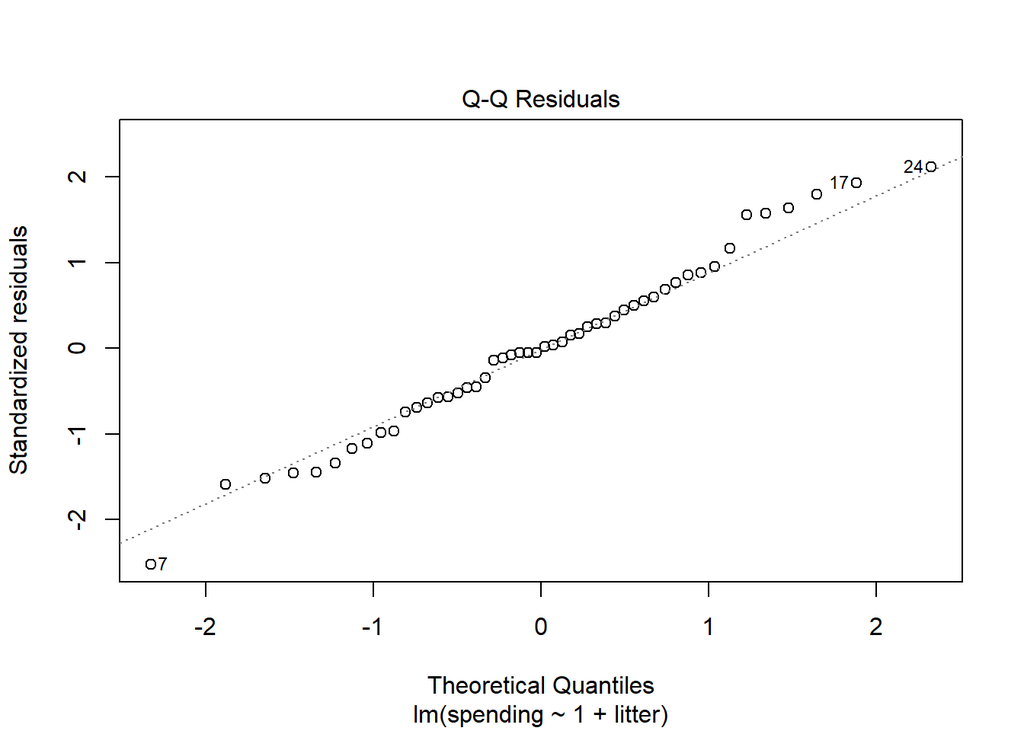

```r
plot(catamaran_lm, which = 2)
```

```r
confint(catamaran_lm, level = 0.95)
```

```
##                 2.5 %    97.5 %
## (Intercept) 21.629927 67.081053
## litter       1.342085  1.851083
```

Based on this confidence interval, we should reject the null hypothesis that β1=0 at level α=0.05, because this suggested value for β1 is outside the range of our confidence interval.

```r
summary(catamaran_lm)$coefficients[,4]
```

```
##  (Intercept)       litter
## 2.767212e-04 7.500063e-17
```

Our coefficient is statistically significantly different from zero (p = 7.500063e-17).

## Problem 3: Understanding the effect of noise (12pts, 2pts each)

This problem, loosely based on Problem 13 in Chapter 3 of [ISLR](https://www.statlearning.com/), will help to give you an intuition to the role of sample size (i.e., number of observations $n$) and noise level (as captured by the variance $\sigma^2$ of the noise terms $\epsilon_i$).

### Part a) generating linear data

Write a function `generate_linear_data` that takes two arguments: `n` and `sigma2`, in that order, and does the following:

1. Use the `rnorm()` function to create a vector `x`, containing `n` independent observations drawn from a normal distribution with mean $0$ and variance $1$. This will represent our vector of predictors. *Note: the $X$ variable need not be normally distributed for linear regression, but it’s a convenient distribution to use.*
2. Use the `rnorm()` function to create a vector, `eps`, containing `n` independent observations drawn from a normal distribution with mean $0$ and variance `sigma2`. These will correspond to the errors in our observed responses.
3. Using `x` and `eps`, construct a vector `y` according to the model
   $$Y = -1 + 0.5X + \epsilon,$$

where $X$ corresponds to entries in our vector `x` and $\epsilon$ corresponds to entries in our vector `eps`.

4. Create a data frame with two columns, `predictors` and `responses` whose entries correspond to the vectors `x` and `y`, respectively. Return this data frame.

You do not need to perform any error checking in this function. You may assume that `n` is a positive integer and `eps` is a positive numeric.

Before writing code, let’s **check your understanding:** What is the length of the vector `y`? What are the values of the intercept $\beta_0$ and slope $\beta_1$ in this linear model?

The lengths of vectors X and Y should be the same, and since vector X has length n, vector Y should also have length n. β0 has a value of -1, and β1 has a value of 0.5.

```r
generate_linear_data = function(n, sigma2) {
  x = rnorm(n)
  eps = rnorm(n, 0, sqrt(sigma2))
  y = -1 + (0.5 * x) + eps
  return(data.frame(predictors = x, responses = y))
}
```

### Part b) Plotting data

Use your function from Part (a) to generate 100 samples from the model
$$Y = -1 + 0.5X + \epsilon,$$

with `sigma2` set to $0.25$ and create a scatterplot of that data, showing the responses $Y$ as a function of $X$. You may use either `ggplot2` or R’s built-in plotting utilities.

Examine the point cloud and discuss: Does the data look approximately linear? Does the slope look about right? What about the intercept? **Note:** You **do not** need to fit a model, yet! Just inspect the data!

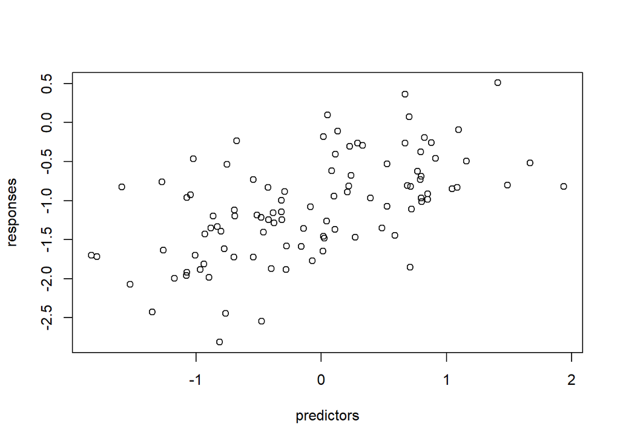

```r
plot(generate_linear_data(100, 0.25))
```

### Part c) the effect of noise

Now, generate 100 data points again, as in part (b), but increase the noise level (i.e., the variance of the observation errors $\epsilon$) to $1$. That is, set `sigma2` to `1`. Plot the data again, and compare to the previous plot. What do you observe?

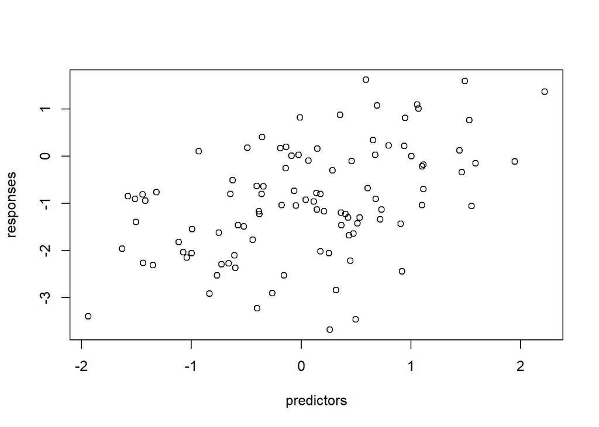

```r
plot(generate_linear_data(100, 1))
```

Compared to the last plot, this plot has less clustering and shows less of a linear trend.

Now, try decreasing the noise level (i.e., the variance of the $\epsilon$ terms), down to $\sigma^2 = 0.1$ and create one more plot, again with $n=100$ data points. What do you observe?

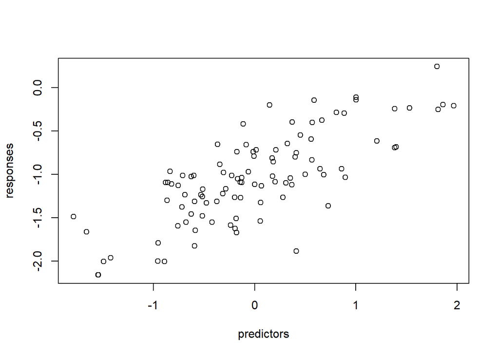

```r
plot(generate_linear_data(100, 0.1))
```

This plot has appears to have more clustering around the underlying trend. This makes the relationship between the predictors and the responses appear clearer and more linear, with less scatter and variation due to noise.

### Part d) estimating from synthetic data

Now, let’s investigate how the amount of noise (i.e., the error term variance $\sigma^2$) influences our estimation of the slope $\beta_1$. Hopefully in your plots above you noticed that when the variance $\sigma^2$ is larger, the linear trend in the data is “harder to see”. Perhaps unsurprisingly, but still interestingly, this translates directly into difficulty in estimating the coefficients. When there is more noise in our observations, our estimation of the coefficients suffers.

Let’s investigate this with a simulation. This part of the problem will have you write code to run a single experiment wherein we generate data and try to estimate the slope $\beta_1$. In Part (e) below, we’ll use this single-trial code to run a Monte Carlo simulation that estimates the variance of our estimate $\hat{\beta}_1$. We’ll be able to see how the variance of our estimate (i.e., how close we are on average to the true $\beta_1$) changes as the noise $\sigma^2$ changes.

Write a function `generate_and_estimate` that takes two arguments: a sample size `n` and a variance term `sigma2`, and does the following:

1. Use `generate_linear_data` to generate a collection of `n` observations from a linear model
   $$Y = -1 + 0.5X + \epsilon,$$
   where the noise term $\epsilon$ is normal with variance `sigma2`.
2. Pass this data into `lm()` to fit a model predicting the column `responses` from the column `predictors` and an intercept term.
3. Extract the estimate of the slope from the resulting fitted model object (hint: look at the `coefficients` attribute of the model object or use the function `coef()`). Call this `beta1hat`. **Hint:** don’t forget to use `unname()` to remove the “names” of the coefficients extracted from the model object.
4. Return `beta1hat`.

```r
generate_and_estimate = function(n, sigma2) {
  lin_dat = generate_linear_data(n, sigma2)
  lin_lm = lm(formula = responses ~ 1 + predictors, data = lin_dat)
  beta1hat = unname(lin_lm$coefficients[2])
  return(beta1hat)
}
```

### Part e) estimating variance of an estimator

Now, let’s write code compute a Monte Carlo estimate of the variance of our estimator $\hat{\beta}_1$. Note that this variance is a good way to measure the (average) squared error of our estimator. When this variance is large, it means that our estimate of $\beta_1$ is more uncertain, as we expect to be farther from the true value of $\beta_1$ more often, on average.

Write a function `estimate_beta1hat_variance` that takes three arguments: a number of observations `n`, a variance `sigma2` and a number of Monte Carlo replicates `M`, and does the following:

1. Use `generate_and_estimate` to generate a collection of `n` observations from a linear model
   $$Y = -1 + 0.5X + \epsilon,$$
   where the noise term $\epsilon$ is normal with variance `sigma2`, and estimate $\beta_1$. Call the resulting estimate `beta1hat`.
2. Perform step 1 a total of `M` times, recording the resulting `beta1hat` each time in a vector. That is, perform `M` Monte Carlo iterations of the experiment wherein we generate random data and estimate the slope $\beta_1 = 0.5$, keeping track of our estimate in each Monte Carlo replicate.
3. Compute and return the variance of our `M` random `beta1hat` replicates. This is a Monte Carlo estimate of the variance of our estimate $\hat{\beta}_1$. You may use either the corrected or uncorrected sample variance in this calculation.

```r
estimate_beta1hat_variance = function(n, sigma2, M) {
  beta1hat_statistics = rep(NA, M)
  for(i in 1:M) {
    beta1hat_statistics[i] = generate_and_estimate(n, sigma2) }
  return(var(beta1hat_statistics))
}
```

### Part f) effect of noise on estimation accuracy

Use your function from Part (e) to create a plot of the variance (as estimated from 1000 Monte Carlo iterates) of the estimator $\hat{\beta}_1$, as a function of $\sigma^2$, when $n=100$. Use values for $\sigma^2$ ranging from $0.25$ to $4$, inclusive, in increments of $0.25$. You may use either `ggplot2` or the built-in R plotting functions.

**Note:** this simulation make take a few minutes to run, since for each value of $\sigma^2$, we must perform $M=1000$ simulations, and each simulation requires fitting linear regression, which is not free!

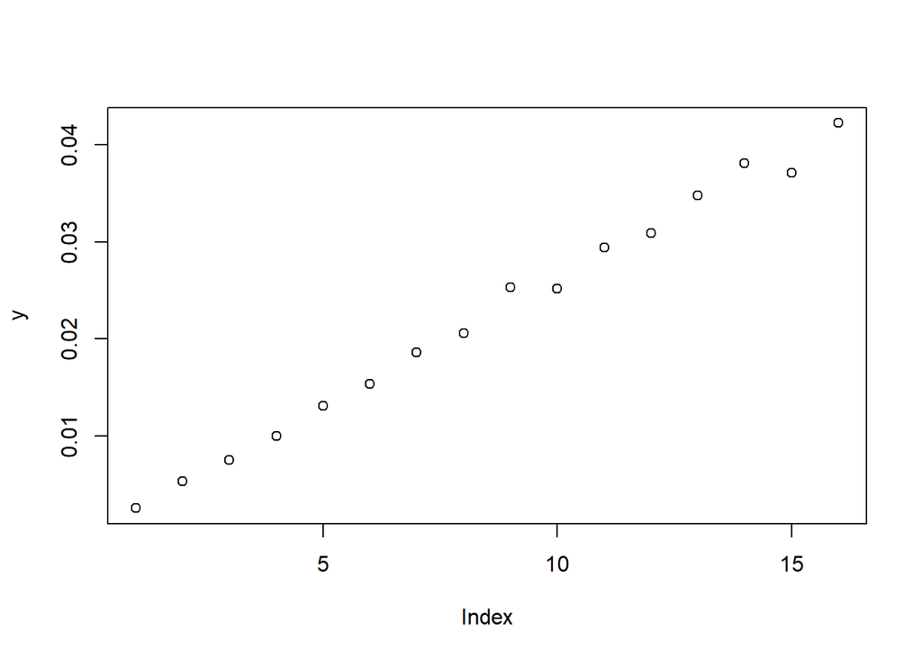

```r
x = seq(0.25, 4, by = 0.25)
y = c()

for(i in x) {
  y = append(y, estimate_beta1hat_variance(100, i, 1e3))
}

plot(y)
```

Based on your plot, how does it look like the variance of our estimator $\hat{\beta}_1$ behaves as a function of the observation error variance $\sigma^2$?

If you look up the variance of $\hat{\beta}_1$ in a mathematical statistics textbook, you will find that
$$\operatorname{Var} \hat{\beta}_1
=
\frac{ \sigma^2 }{ \sum_{i=1}^n (x_i - \bar{x})^2 }.$$

## Problem 4: Assessing Assumptions (6 points, 1pt each)

1325 UCLA students were asked to fill out a survey where they were asked about their height (inches), fastest speed they have ever driven (miles per hour), and gender. Here we will focus only on the fastest speed and the height.

The dataset can be downloaded [here](https://vincentarelbundock.github.io/Rdatasets/csv/openintro/speed_gender_height.csv). The dataset will need to be cleaned a little bit before you can fit a good model. Removing some rows of data will not greatly affect conclusions since there are so many rows.

### Part a) Load and clean the data

Load the data and clean it so you can proceed. Explain what you did to clean the data and how many rows were removed.

```r
data = read.csv("speed_gender_height.csv")

str(data)
```

```
## 'data.frame':    1325 obs. of  4 variables:
##  $ rownames: int  1 2 3 4 5 6 7 8 9 10 ...
##  $ speed   : int  85 40 87 110 110 120 90 90 80 95 ...
##  $ gender  : chr  "female" "male" "female" "female" ...
##  $ height  : num  69 71 64 60 70 61 65 65 61 69 ...
```

```r
summary(data)
```

```
##     rownames        speed           gender              height
##  Min.   :   1   Min.   :  0.00   Length:1325        Min.   :52.00
##  1st Qu.: 332   1st Qu.: 80.00   Class :character   1st Qu.:63.00
##  Median : 663   Median : 90.00   Mode  :character   Median :66.00
##  Mean   : 663   Mean   : 90.73                      Mean   :66.13
##  3rd Qu.: 994   3rd Qu.:100.00                      3rd Qu.:69.00
##  Max.   :1325   Max.   :185.00                      Max.   :82.00
##                 NA's   :18                          NA's   :5
```

```r
clean_data = subset(data, !is.na(height) & !is.na(speed) &
                     height > 40 & height < 90 &
                     speed > 0)

n_removed = nrow(data) - nrow(clean_data)
cat("Rows removed:", n_removed, "\n")
```

```
## Rows removed: 46
```

I loaded the data set using read.csv. To clean the data, I removed any rows that had missing values in the speed or height columns, heights less than 40 inches or greater than 90 inches, and speeds less than or equal to 0 mph. After applying these, I removed 46 rows, resulting in a clean dataset with 1,279 observations.

### Part b) Fit the model

Fit a linear model predicting `speed` from `height`. Report the coefficients. For each coefficient provide a meaningful interpretation of the coefficient estimate. If not appropriate explain why.

```r
model = lm(speed ~ height, data = clean_data)

summary(model)
```

```
##
## Call:
## lm(formula = speed ~ height, data = clean_data)
##
## Residuals:
##     Min      1Q  Median      3Q     Max
## -73.460  -9.612   0.301  10.301  81.671
##
## Coefficients:
##             Estimate Std. Error t value Pr(>|t|)
## (Intercept)  10.3958     8.3929   1.239    0.216
## height        1.2391     0.1266   9.787   <2e-16 ***
## ---
## Signif. codes:  0 '***' 0.001 '**' 0.01 '*' 0.05 '.' 0.1 ' ' 1
##
## Residual standard error: 18.37 on 1277 degrees of freedom
## Multiple R-squared:  0.06977,    Adjusted R-squared:  0.06905
## F-statistic: 95.78 on 1 and 1277 DF,  p-value: < 2.2e-16
```

```r
coef(model)
```

```
## (Intercept)      height
##   10.395783    1.239112
```

The intercept of 10.40 means that if a student had a height of 0 inches, their predicted speed would be 10.40 mph. The slope of 1.24 means that for each additional inch in height, a student’s fastest driving speed is expected to increase by approximately 1.24 mph on average.The very small p-value indicates that height is a statistically significant predictor of speed. However, the R^2 value shows that height explains only about 7% of the variation in driving speed, suggesting other factors likely play a much larger role.

### Part c) Linearity Assumption

Choose an appropriate diagnostic plot to assess the zero-mean assumption of the error term (i.e. linearity assumption). Do you see any evidence that the assumption is violated? Be specific.

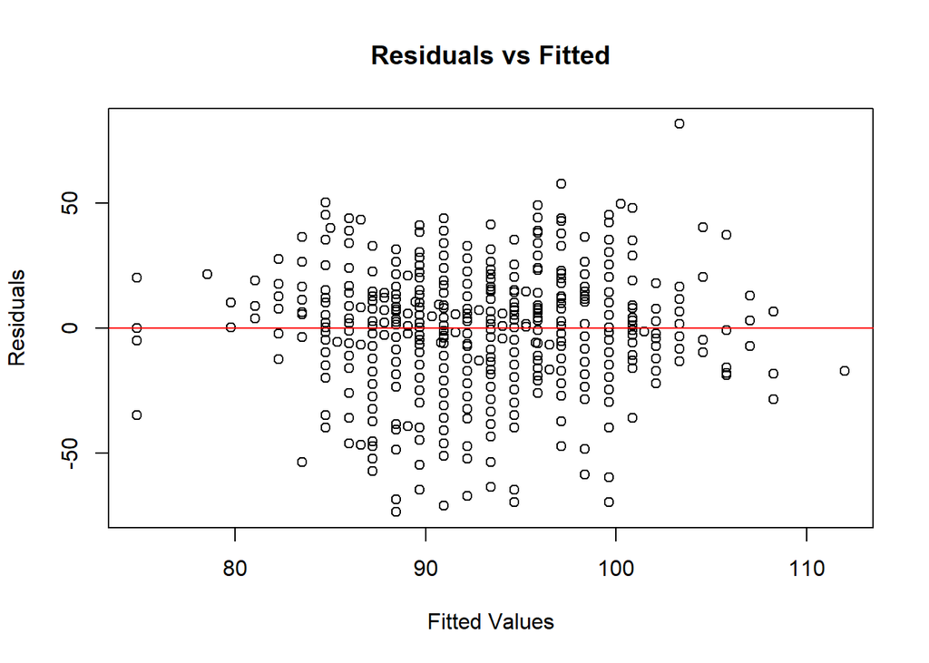

```r
plot(model$fitted.values, model$residuals,
     xlab = "Fitted Values", ylab = "Residuals",
     main = "Residuals vs Fitted")
abline(h = 0, col = "red")
```

Check if residuals are randomly scattered. A curve indicates non-linearity.

### Part d) Normality Assumption

Choose an appropriate diagnostic plot to assess the normality assumption of the error term. Do you see any evidence that the assumption is violated? Be specific.

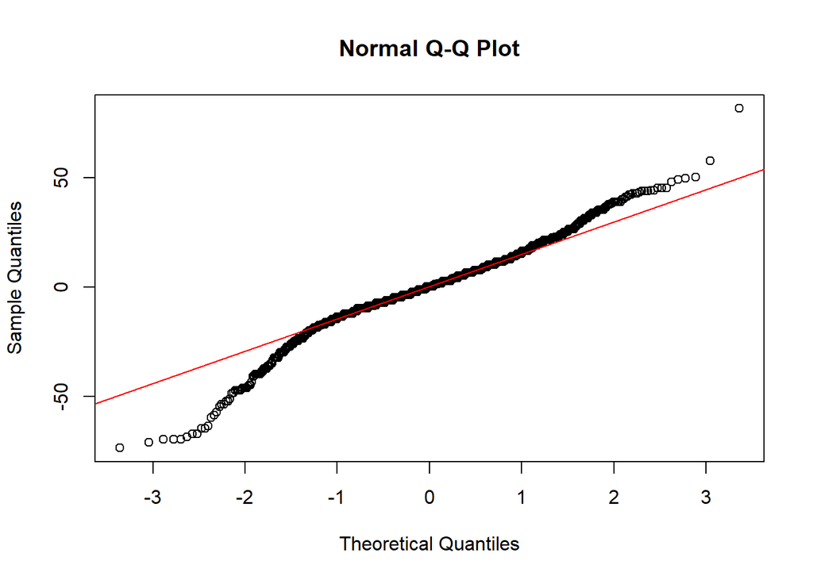

```r
qqnorm(model$residuals)
qqline(model$residuals, col = "red")
```

Check if points fall along the line. Deviations suggest non-normal errors.

### Part e) Equal Variance Assumption

Choose an appropriate diagnostic plot to assess the equal variance assumption of the error term. Do you see any evidence that the assumption is violated? Be specific.

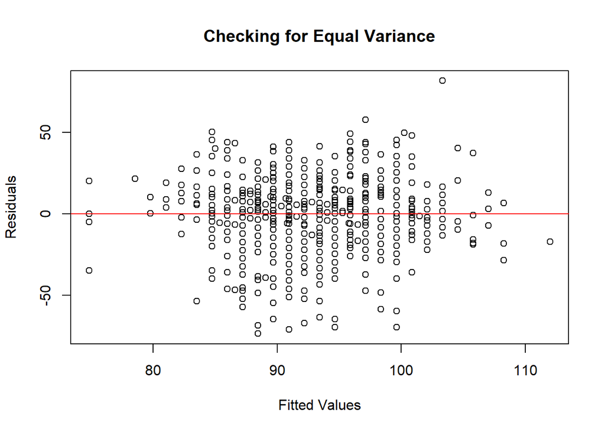

```r
plot(model$fitted.values, model$residuals,
     xlab = "Fitted Values", ylab = "Residuals",
     main = "Checking for Equal Variance")
abline(h = 0, col = "red")
```

### Part f) Coefficient of Determination

Report the Coefficient of determination $R^2$. Interpret this statistic in a sentence relating to the values of `speed` reported by the students.

```r
r_squared <- summary(model)$r.squared
cat("R-squared:", r_squared, "\n")
```

```
## R-squared: 0.06977363
```